# Homework(6-5,6-7)

Hwang Seong-Yun

2020 11 5

### packages

```r
library(survival)
library(KMsurv)
library(tidyverse)
library(survminer)
```

## 연습문제 6-5) 다음은 F98 glioma(신경교종 : 중추신경의 신경교조직에서 발생하는 종양) 치료에 boron neutron capture therapy(BNCT : 붕소 중성자 치료)의 효과를 알아보기 위한 연구 결과이다. 실험쥐를 세 그룹으로 랜덤하게 배정한 후 각 실험쥐의 뇌에 F98 glioma cell을 이식한 후 사망까지의 시간 데이터이다. 처리하지 않은 대조 그룹, 방사선을 쪼인 그룹, 방사선요법과 boronophenylanine(BPA)를 같이 처리한 그룹에 대해 실험한 결과는 다음과 같다.

```r
BPA <- tibble(time=c(20,21,23,24,24,26,26,27,28,30,26,28,29,30,30,31,31,32,29,35,31,32,34,35,36,38,38,42,39,42),censor=c(rep(1,10),rep(1,9),0,rep(1,7),0,rep(1,2)),method=c(rep("untreated",10),rep("radiated",10),rep("radiated+BPA",10)))
BPA
```

```
## # A tibble: 30 x 3
##     time censor method
##    <dbl>  <dbl> <chr>
##  1    20      1 untreated
##  2    21      1 untreated
##  3    23      1 untreated
##  4    24      1 untreated
##  5    24      1 untreated
##  6    26      1 untreated
##  7    26      1 untreated
##  8    27      1 untreated
##  9    28      1 untreated
## 10    30      1 untreated
## # ... with 20 more rows
```

### (1) 그룹별 Kaplan-Meier 생존함수 그림을 한 평면에 그리시오.

```r
attach(BPA)
Surv(time, censor)
```

```
##  [1] 20  21  23  24  24  26  26  27  28  30  26  28  29  30  30  31  31  32  29
## [20] 35+ 31  32  34  35  36  38  38  42+ 39  42
```

```r
fit <- survfit(Surv(time, censor) ~ method, data=BPA)
summary(fit)
```

```
## Call: survfit(formula = Surv(time, censor) ~ method, data = BPA)
##
##                 method=radiated
##  time n.risk n.event survival std.err lower 95% CI upper 95% CI
##    26     10       1      0.9  0.0949       0.7320        1.000
##    28      9       1      0.8  0.1265       0.5868        1.000
##    29      8       2      0.6  0.1549       0.3617        0.995
##    30      6       2      0.4  0.1549       0.1872        0.855
##    31      4       2      0.2  0.1265       0.0579        0.691
##    32      2       1      0.1  0.0949       0.0156        0.642
##
##                 method=radiated+BPA
##  time n.risk n.event survival std.err lower 95% CI upper 95% CI
##    31     10       1      0.9  0.0949       0.7320        1.000
##    32      9       1      0.8  0.1265       0.5868        1.000
##    34      8       1      0.7  0.1449       0.4665        1.000
##    35      7       1      0.6  0.1549       0.3617        0.995
##    36      6       1      0.5  0.1581       0.2690        0.929
##    38      5       2      0.3  0.1449       0.1164        0.773
##    39      3       1      0.2  0.1265       0.0579        0.691
##    42      2       1      0.1  0.0949       0.0156        0.642
##
##                 method=untreated
##  time n.risk n.event survival std.err lower 95% CI upper 95% CI
##    20     10       1      0.9  0.0949       0.7320        1.000
##    21      9       1      0.8  0.1265       0.5868        1.000
##    23      8       1      0.7  0.1449       0.4665        1.000
##    24      7       2      0.5  0.1581       0.2690        0.929
##    26      5       2      0.3  0.1449       0.1164        0.773
##    27      3       1      0.2  0.1265       0.0579        0.691
##    28      2       1      0.1  0.0949       0.0156        0.642
##    30      1       1      0.0     NaN           NA           NA
```

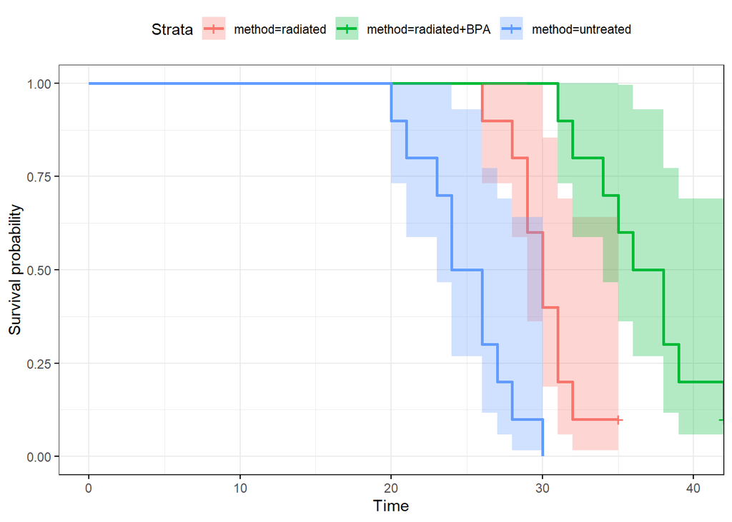

```r
ggsurvplot(fit,
          conf.int = TRUE,
          risk.table.col = "strata", # Change risk table color by groups
          ggtheme = theme_bw()
)
```

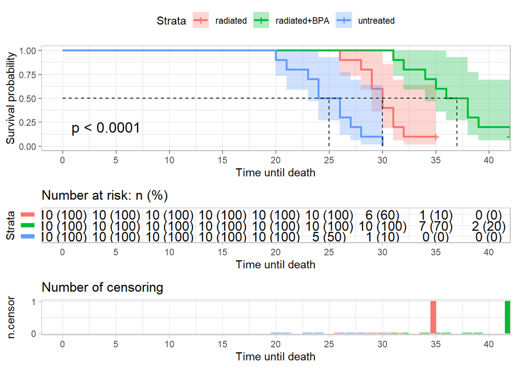

```r
ggsurvplot(
   fit,                     # survfit object with calculated statistics.
   pval = TRUE,             # show p-value of log-rank test.
   conf.int = TRUE,         # show confidence intervals for
                            # point estimaes of survival curves.
   xlab = "Time until death",   # customize X axis label.
   break.time.by = 5,     # break X axis in time intervals by 200.
   ggtheme = theme_light(), # customize plot and risk table with a theme.
   risk.table = "abs_pct",  # absolute number and percentage at risk.
  risk.table.y.text.col = T,# colour risk table text annotations.
  risk.table.y.text = FALSE,# show bars instead of names in text annotations
                            # in legend of risk table.
  ncensor.plot = TRUE,      # plot the number of censored subjects at time t
  surv.median.line = "hv",  # add the median survival pointer.
  legend.labs =
    c("radiated", "radiated+BPA", "untreated"),    # change legend labels.
)
```

### (2) 그룹별 생존함수가 같다고 할 수 있는지 유의수준 alpha=0.05 에서 log-rank test를 수행하시오.

#### H0 : 그룹별 생존함수가 같다. / H1 : not H0

```r
survdiff(Surv(time, censor) ~ method, data=BPA, rho=0)
```

```
## Call:
## survdiff(formula = Surv(time, censor) ~ method, data = BPA, rho = 0)
##
##                      N Observed Expected (O-E)^2/E (O-E)^2/V
## method=radiated     10        9     7.60     0.258     0.431
## method=radiated+BPA 10        9    17.74     4.308    16.587
## method=untreated    10       10     2.66    20.300    27.365
##
##  Chisq= 33.4  on 2 degrees of freedom, p= 6e-08
```

#### Chi-square test statistic = 33.4 / p-value = 6*10^(-8) < alpha=0.05

#### Reject H0 -> 그룹별 생존함수가 같다고 할 수 없다.

## 연습문제 6-7) 90마리의 실험쥐(종 나이, 신체조건이 비슷)에 대해 식이요법과 종양과의 관계를 알아보고자 한다. 다음은 종양세포(tumor cell) 주입 후 저지방(low-fat), 포화지방(saturated), 불포화지방(unsaturated) 식이요법을 한 후 200일 실험기간동안 조사한 데이터이다. 식이요법에 따라 생존시간이 다르다고 할 수 있는지 검정하시오.

### data

```r
tumor <- tibble(time=c(140,177,50,65,86,153,181,191,77,84,87,56,66,73,119,140,200,201,202,203,204,205,206,207,208,209,210,211,212,213,124,58,56,68,79,89,107,86,142,110,96,142,86,75,117,98,105,126,43,46,81,133,165,170,200,201,202,203,204,205,112,68,84,109,153,143,60,70,98,164,63,63,77,91,91,66,70,77,63,66,66,94,101,105,108,112,115,126,181,178),censor=c(rep(1,15),rep(0,15),rep(1,23),rep(0,7),rep(1,30)),method=c(rep("low-fat",30),rep("saturated",30),rep("unsaturated",30)))
tumor
```

```
## # A tibble: 90 x 3
##     time censor method
##    <dbl>  <dbl> <chr>
##  1   140      1 low-fat
##  2   177      1 low-fat
##  3    50      1 low-fat
##  4    65      1 low-fat
##  5    86      1 low-fat
##  6   153      1 low-fat
##  7   181      1 low-fat
##  8   191      1 low-fat
##  9    77      1 low-fat
## 10    84      1 low-fat
## # ... with 80 more rows
```

### Graph of Kaplan-Meier Survival function

```r
attach(tumor)
Surv(time, censor)
```

```
##  [1] 140  177   50   65   86  153  181  191   77   84   87   56   66   73  119
## [16] 140+ 200+ 201+ 202+ 203+ 204+ 205+ 206+ 207+ 208+ 209+ 210+ 211+ 212+ 213+
## [31] 124   58   56   68   79   89  107   86  142  110   96  142   86   75  117
## [46]  98  105  126   43   46   81  133  165  170+ 200+ 201+ 202+ 203+ 204+ 205+
## [61] 112   68   84  109  153  143   60   70   98  164   63   63   77   91   91
## [76]  66   70   77   63   66   66   94  101  105  108  112  115  126  181  178
```

```r
fit <- survfit(Surv(time, censor) ~ method, data=tumor)
summary(fit)
```

```
## Call: survfit(formula = Surv(time, censor) ~ method, data = tumor)
##
##                 method=low-fat
##  time n.risk n.event survival std.err lower 95% CI upper 95% CI
##    50     30       1    0.967  0.0328        0.905        1.000
##    56     29       1    0.933  0.0455        0.848        1.000
##    65     28       1    0.900  0.0548        0.799        1.000
##    66     27       1    0.867  0.0621        0.753        0.997
##    73     26       1    0.833  0.0680        0.710        0.978
##    77     25       1    0.800  0.0730        0.669        0.957
##    84     24       1    0.767  0.0772        0.629        0.934
##    86     23       1    0.733  0.0807        0.591        0.910
##    87     22       1    0.700  0.0837        0.554        0.885
##   119     21       1    0.667  0.0861        0.518        0.859
##   140     20       1    0.633  0.0880        0.482        0.832
```

[output cut: 53 more lines]

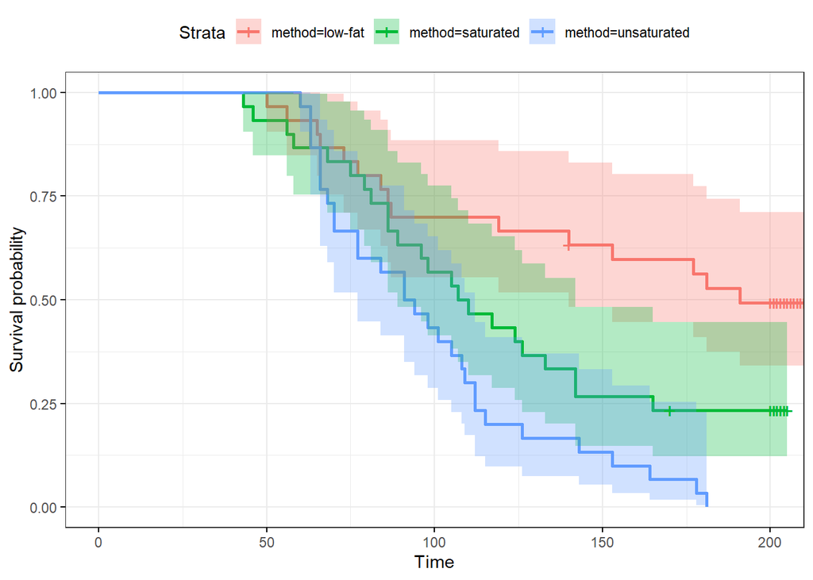

```r
ggsurvplot(fit,
          conf.int = TRUE,
          risk.table.col = "strata", # Change risk table color by groups
          ggtheme = theme_bw()
)
```

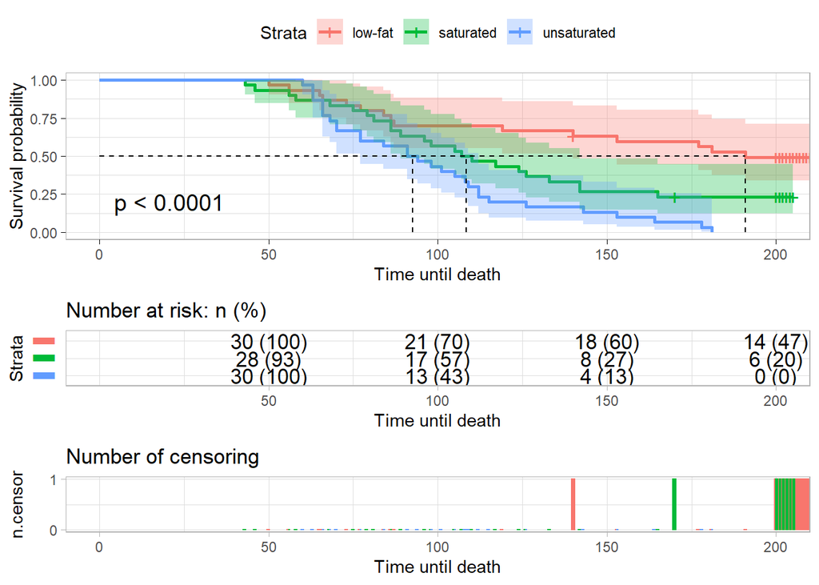

```r
ggsurvplot(
   fit,                     # survfit object with calculated statistics.
   pval = TRUE,             # show p-value of log-rank test.
   conf.int = TRUE,         # show confidence intervals for
                            # point estimaes of survival curves.
   xlab = "Time until death",   # customize X axis label.
   ggtheme = theme_light(), # customize plot and risk table with a theme.
   risk.table = "abs_pct",  # absolute number and percentage at risk.
  risk.table.y.text.col = T,# colour risk table text annotations.
  risk.table.y.text = FALSE,# show bars instead of names in text annotations
                            # in legend of risk table.
  ncensor.plot = TRUE,      # plot the number of censored subjects at time t
  surv.median.line = "hv",  # add the median survival pointer.
  legend.labs =
    c("low-fat", "saturated", "unsaturated"),    # change legend labels.
)
```

#### H0 : 식이요법에 관계없이 생존함수는 동일하다. / H1 : not H0

```r
survdiff(Surv(time, censor) ~ method, data=tumor, rho=0)
```

```
## Call:
## survdiff(formula = Surv(time, censor) ~ method, data = tumor,
##     rho = 0)
##
##                     N Observed Expected (O-E)^2/E (O-E)^2/V
## method=low-fat     30       15     29.7    7.2911   13.8189
## method=saturated   30       23     22.0    0.0501    0.0753
## method=unsaturated 30       30     16.3   11.4481   15.9860
##
##  Chisq= 20.3  on 2 degrees of freedom, p= 4e-05
```

#### Chi-square test statistic = 20.3 / p-value = 4*10^(-5) < alpha=0.05

#### Reject H0 -> 식이요법에 따라 생존함수는 달라진다.